# Analyse de la Couverture du Sol des Communes

Classification paysagère basée sur CLC+ Backbone 2018

Author

Eric Delmelle (pour Paris8)

Published

October 20, 2025

# 1 Introduction

Ce document présente une analyse complète de la couverture du sol pour les communes de la région parisienne, basée sur les données **CLC+ Backbone 2018** à une résolution de 10 mètres.

L’analyse comprend trois étapes principales :

1. **Extraction des données** : calcul du pourcentage de chaque classe de couverture du sol par commune
2. **Analyse en Composantes Principales (ACP)** : réduction dimensionnelle pour identifier les gradients paysagers dominants
3. **Classification K-means** : typologie paysagère des communes

## 1.1 Classes CLC+ Backbone

Le référentiel CLC+ Backbone comprend 11 classes de couverture du sol :

- **Classe 1** : Surfaces artificielles
- **Classe 2** : Forêts de feuillus
- **Classe 3** : Forêts de conifères
- **Classe 4** : Forêts mixtes
- **Classe 5** : Végétation arbustive/herbacée naturelle
- **Classe 6** : Prairies
- **Classe 7** : Cultures
- **Classe 8** : Zones humides intérieures
- **Classe 9** : Zones humides côtières
- **Classe 10** : Plans d’eau
- **Classe 11** : Espaces marins

# 2 1. Configuration et chargement des données

## 2.1 Installation et chargement des packages

```r
# Liste des packages nécessaires
pkgs <- c("sf", "terra", "exactextractr", "FactoMineR", "cluster",
          "factoextra", "dplyr", "tidyr", "ggplot2", "tmap", "knitr", "patchwork")

# Installation automatique si nécessaire
to_install <- setdiff(pkgs, rownames(installed.packages()))
if (length(to_install)) {
  install.packages(to_install, repos = "https://cloud.r-project.org")
}

# Chargement des bibliothèques
library(sf)
library(terra)
library(exactextractr)
library(FactoMineR)
library(factoextra)
library(cluster)
library(dplyr)
library(tidyr)
library(ggplot2)
library(tmap)
library(knitr)
library(patchwork)
```

## 2.2 Chargement du raster CLC+

Le raster CLC+ est en projection **EPSG:3035** (ETRS89 / LAEA Europe), optimisée pour l’analyse à l’échelle européenne.

```r
# Chemin vers le raster
raster_path <- "CLCplus_2018_010m.tif"
raster_clc <- rast(raster_path)

# Définition WKT pour EPSG:3035 (si nécessaire)
wkt3035 <- 'PROJCRS["ETRS89-extended / LAEA Europe",
  BASEGEOGCRS["ETRS89",
    DATUM["European Terrestrial Reference System 1989",
      ELLIPSOID["GRS 1980",6378137,298.257222101]],
    PRIMEM["Greenwich",0]],
  CONVERSION["Lambert Azimuthal Equal Area",
    METHOD["Lambert Azimuthal Equal Area"],
    PARAMETER["Latitude of natural origin",52],
    PARAMETER["Longitude of natural origin",10],
    PARAMETER["False easting",4321000],
    PARAMETER["False northing",3210000]],
  CS[Cartesian,2],
    AXIS["easting (X)",east],
    AXIS["northing (Y)",north],
    LENGTHUNIT["metre",1],
  ID["EPSG",3035]]'

# Assigner la projection si manquante
if (is.na(crs(raster_clc)) || crs(raster_clc) == "") {
  crs(raster_clc) <- wkt3035
}

# Vérifications
cat("📊 Résolution:", res(raster_clc), "m\n")
```

```
📊 Résolution: 10 10 m
```

```r
cat("🗺️  Projection:", as.character(crs(raster_clc, proj = TRUE)), "\n")
```

```
🗺️  Projection: +proj=laea +lat_0=52 +lon_0=10 +x_0=4321000 +y_0=3210000 +ellps=GRS80 +units=m +no_defs
```

## 2.3 Chargement des communes

Les communes ont été présélectionnées pour être entièrement couvertes par le raster.

```r
# Lecture du shapefile des communes
communes <- st_read("communesIn.shp", quiet = TRUE)

# Reprojection vers EPSG:3035 si nécessaire
if (st_crs(communes) != crs(raster_clc)) {
  communes <- st_transform(communes, crs(raster_clc))
}

cat("🏘️  Nombre de communes:", nrow(communes), "\n")
```

```
🏘️  Nombre de communes: 502
```

# 3 2. Extraction des statistiques par commune

L’extraction utilise le package `exactextractr` qui calcule les proportions exactes de chaque pixel intersectant les polygones communaux, en tenant compte des fractions de couverture.

**Méthode d’extraction**

L’algorithme `exact_extract` considère la fraction de chaque pixel recouverte par chaque polygone communal, ce qui garantit une précision maximale dans le calcul des pourcentages.

```r
# Extraction pour toutes les communes avec barre de progression
results_df <- exactextractr::exact_extract(
  raster_clc,
  communes,
  fun = function(values, coverage_fractions) {
    # Création d'un dataframe valeurs × poids
    df <- data.frame(val = values, w = coverage_fractions)

    # Filtrer uniquement les classes CLC+ valides (1-11)
    df <- df[!is.na(df$val) & df$val %in% 1:11, ]

    # Si aucune donnée, retourner des zéros
    if (nrow(df) == 0) return(rep(0, 11))

    # Agréger par classe et calculer les pourcentages
    agg <- aggregate(w ~ val, df, sum)
    pct <- numeric(11)
    pct[agg$val] <- 100 * agg$w / sum(agg$w)

    return(pct)
  },
  progress = FALSE
)
```

## 3.1 Assemblage des résultats

```r
# Vérifier si transposition nécessaire
if (is.matrix(results_df) && nrow(results_df) == 11 && ncol(results_df) == nrow(communes)) {
  results_df <- t(results_df)
}

# Conversion en data.frame
results_df <- as.data.frame(results_df)
colnames(results_df) <- paste0("class_", 1:11)
rownames(results_df) <- NULL

# Vérification des dimensions
stopifnot(nrow(results_df) == nrow(communes))

# Fusion avec les données communales
communes_clc <- bind_cols(communes, results_df)

# Aplatissement des colonnes si nécessaire (format liste)
class_cols <- paste0("class_", 1:11)
for (cc in class_cols) {
  x <- communes_clc[[cc]]
  if (is.list(x)) x <- unlist(x, recursive = TRUE, use.names = FALSE)
  x <- suppressWarnings(as.numeric(x))
  if (length(x) < nrow(communes_clc)) {
    x <- rep_len(x, nrow(communes_clc))
  }
  communes_clc[[cc]] <- x
}

cat("✅ Extraction terminée pour", nrow(communes_clc), "communes\n")
```

```
✅ Extraction terminée pour 502 communes
```

## 3.2 Statistiques descriptives

```r
# Aperçu des premières communes
kable(
  head(communes_clc %>%
    st_drop_geometry() %>%
    select(NOM_COM, starts_with("class_")), 10),
  digits = 2,
  caption = "Pourcentage de couverture par classe pour les 10 premières communes"
)
```

Pourcentage de couverture par classe pour les 10 premières communes

| NOM_COM | class_1 | class_2 | class_3 | class_4 | class_5 | class_6 | class_7 | class_8 | class_9 | class_10 | class_11 |
| --- | --- | --- | --- | --- | --- | --- | --- | --- | --- | --- | --- |
| Bernay-Vilbert | 2.90 | 0.62 | 32.08 | 0 | 0.06 | 13.96 | 49.66 | 0 | 0.50 | 0.21 | 0 |
| Montmachoux | 2.49 | 0.05 | 11.29 | 0 | 0.28 | 8.37 | 77.52 | 0 | 0.00 | 0.00 | 0 |
| Corbeil-Essonnes | 64.64 | 0.15 | 18.20 | 0 | 0.12 | 11.21 | 1.28 | 0 | 0.29 | 4.11 | 0 |
| Tousson | 1.56 | 0.15 | 3.35 | 0 | 0.01 | 4.39 | 90.48 | 0 | 0.06 | 0.00 | 0 |
| Tigery | 15.83 | 0.02 | 46.43 | 0 | 0.10 | 12.77 | 23.85 | 0 | 0.65 | 0.33 | 0 |
| Esmans | 3.08 | 0.21 | 7.28 | 0 | 0.34 | 7.10 | 81.96 | 0 | 0.02 | 0.01 | 0 |
| Pontcarré | 5.18 | 0.85 | 85.79 | 0 | 0.23 | 7.27 | 0.54 | 0 | 0.13 | 0.01 | 0 |
| Samoreau | 15.49 | 0.54 | 60.81 | 0 | 0.01 | 16.58 | 0.16 | 0 | 0.07 | 6.34 | 0 |
| Moisenay | 6.57 | 0.01 | 21.33 | 0 | 0.26 | 15.53 | 55.34 | 0 | 0.66 | 0.30 | 0 |
| Villiers-sur-Orge | 43.71 | 0.06 | 19.99 | 0 | 0.05 | 18.62 | 16.79 | 0 | 0.78 | 0.00 | 0 |

```r
# Statistiques globales
cat("\n📈 Statistiques par classe (% moyen):\n")
```

```
📈 Statistiques par classe (% moyen):
```

```r
moyennes <- communes_clc %>%
  st_drop_geometry() %>%
  select(starts_with("class_")) %>%
  summarise(across(everything(), mean, na.rm = TRUE))

kable(t(moyennes), col.names = "Moyenne (%)", digits = 2)
```

|  | Moyenne (%) |
| --- | --- |
| class_1 | 28.18 |
| class_2 | 1.09 |
| class_3 | 28.09 |
| class_4 | 0.00 |
| class_5 | 0.15 |
| class_6 | 12.32 |
| class_7 | 28.42 |
| class_8 | 0.00 |
| class_9 | 0.41 |
| class_10 | 1.34 |
| class_11 | 0.00 |

# 4 3. Cartographie des classes

Cette section présente la répartition spatiale de chaque classe de couverture du sol.

## 4.1 Carte facettée des 11 classes

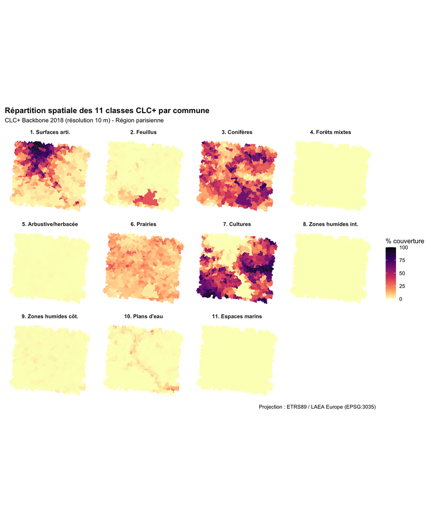

```r
# Dictionnaire des noms de classes
clc_labels <- c(
  "class_1"  = "1. Surfaces arti.",
  "class_2"  = "2. Feuillus",
  "class_3"  = "3. Conifères",
  "class_4"  = "4. Forêts mixtes",
  "class_5"  = "5. Arbustive/herbacée",
  "class_6"  = "6. Prairies",
  "class_7"  = "7. Cultures",
  "class_8"  = "8. Zones humides int.",
  "class_9"  = "9. Zones humides côt.",
  "class_10" = "10. Plans d'eau",
  "class_11" = "11. Espaces marins"
)

# Format long pour ggplot
communes_long <- communes_clc %>%
  select(all_of(names(clc_labels)), NOM_COM, geometry) %>%
  pivot_longer(
    cols = all_of(names(clc_labels)),
    names_to = "classe",
    values_to = "pourcentage"
  ) %>%
  mutate(classe = factor(classe, levels = names(clc_labels), labels = clc_labels))

# Carte facettée
ggplot(communes_long) +
  geom_sf(aes(fill = pourcentage), color = NA) +
  scale_fill_viridis_c(
    option = "magma",
    direction = -1,
    name = "% couverture",
    limits = c(0, 100)
  ) +
  facet_wrap(~classe, ncol = 4) +
  labs(
    title = "Répartition spatiale des 11 classes CLC+ par commune",
    subtitle = "CLC+ Backbone 2018 (résolution 10 m) - Région parisienne",
    caption = "Projection : ETRS89 / LAEA Europe (EPSG:3035)"
  ) +
  theme_minimal(base_size = 11) +
  theme(
    legend.position = "right",
    axis.text = element_blank(),
    axis.title = element_blank(),
    panel.grid = element_blank(),
    strip.text = element_text(face = "bold", size = 9),
    plot.title = element_text(face = "bold", size = 13),
    plot.subtitle = element_text(size = 10)
  )
```

**Observations**

Les classes 1 (surfaces artificielles), 3 (conifères) et 7 (cultures) présentent les contrastes spatiaux les plus marqués, révélant des structures paysagères distinctes.

# 5 4. Analyse en Composantes Principales (ACP)

L’ACP permet de réduire les 11 dimensions (classes) en quelques axes synthétiques qui capturent les principaux gradients paysagers.

**Objectif de l’ACP**

Identifier les combinaisons de classes qui varient conjointement et révèlent des gradients paysagers structurants (urbain/rural, forestier/agricole, etc.).

## 5.1 Calcul de l’ACP

```r
# Extraction des données pour l'ACP (sans géométrie)
data_pca <- communes_clc %>%
  st_drop_geometry() %>%
  select(all_of(class_cols))

# ACP avec centrage et réduction
pca_res <- PCA(data_pca, scale.unit = TRUE, graph = FALSE)

# Résumé
cat("🔍 Variance expliquée par les 5 premiers axes:\n")
```

```
🔍 Variance expliquée par les 5 premiers axes:
```

```r
print(round(pca_res$eig[1:5, 2], 2))
```

```
comp 1 comp 2 comp 3 comp 4 comp 5
 24.23  22.96  16.33  11.35  10.79
```

```r
cat("\n📊 Variance cumulée (5 axes):",
    round(pca_res$eig[5, 3], 2), "%\n")
```

```
📊 Variance cumulée (5 axes): 85.66 %
```

## 5.2 Éboulis des valeurs propres

Ce graphique montre la part de variance expliquée par chaque composante principale.

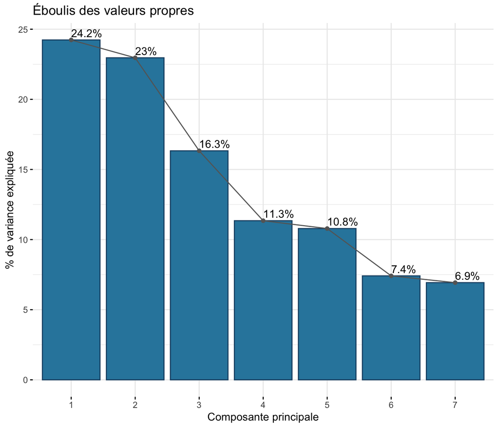

```r
fviz_eig(
  pca_res,
  addlabels = TRUE,
  barfill = "#2E86AB",
  barcolor = "#1B4F72",
  linecolor = "grey40",
  ncp = 7,
  main = "Éboulis des valeurs propres",
  xlab = "Composante principale",
  ylab = "% de variance expliquée"
)
```

## 5.3 Cercle des corrélations

Ce graphique montre comment les variables originales se projettent sur les deux premiers axes principaux.

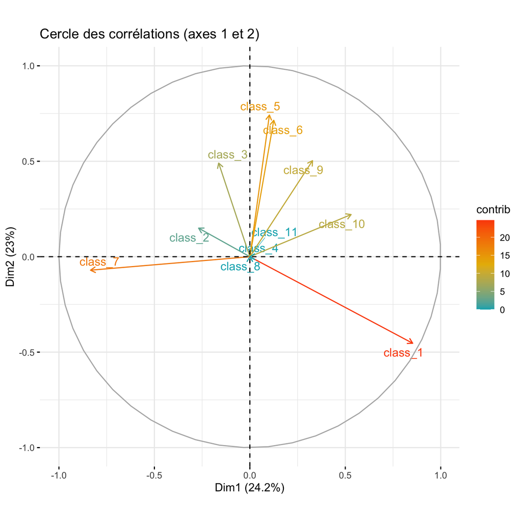

```r
fviz_pca_var(
  pca_res,
  col.var = "contrib",
  gradient.cols = c("#00AFBB", "#E7B800", "#FC4E07"),
  repel = TRUE,
  title = "Cercle des corrélations (axes 1 et 2)"
)
```

### 5.3.1 Contributions aux axes

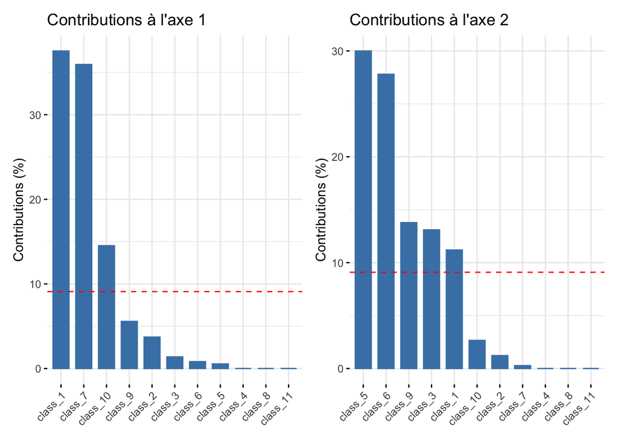

```r
# Contributions des variables aux deux premiers axes
p_contrib1 <- fviz_contrib(pca_res, choice = "var", axes = 1, top = 11) +
  labs(title = "Contributions à l'axe 1")

p_contrib2 <- fviz_contrib(pca_res, choice = "var", axes = 2, top = 11) +
  labs(title = "Contributions à l'axe 2")

p_contrib1 | p_contrib2
```

### 5.3.2 Interprétation des axes

```r
# Tableau des coordonnées (loadings)
loadings <- as.data.frame(round(pca_res$var$coord[, 1:5], 3))
loadings$Variable <- rownames(loadings)
loadings <- loadings[, c(6, 1:5)]

kable(
  loadings,
  caption = "Corrélations entre les variables et les 5 premiers axes principaux",
  col.names = c("Variable", "Axe 1", "Axe 2", "Axe 3", "Axe 4", "Axe 5")
)
```

Corrélations entre les variables et les 5 premiers axes principaux

|  | Variable | Axe 1 | Axe 2 | Axe 3 | Axe 4 | Axe 5 |
| --- | --- | --- | --- | --- | --- | --- |
| class_1 | class_1 | 0.853 | -0.453 | 0.011 | 0.128 | -0.133 |
| class_2 | class_2 | -0.268 | 0.150 | 0.531 | 0.724 | 0.201 |
| class_3 | class_3 | -0.163 | 0.490 | 0.733 | -0.289 | -0.131 |
| class_4 | class_4 | 0.000 | 0.000 | 0.000 | 0.000 | 0.000 |
| class_5 | class_5 | 0.103 | 0.742 | -0.177 | -0.048 | 0.212 |
| class_6 | class_6 | 0.125 | 0.715 | -0.191 | -0.102 | -0.385 |
| class_7 | class_7 | -0.835 | -0.071 | -0.499 | -0.001 | 0.216 |
| class_8 | class_8 | 0.000 | 0.000 | 0.000 | 0.000 | 0.000 |
| class_9 | class_9 | 0.328 | 0.503 | -0.411 | 0.482 | -0.109 |
| class_10 | class_10 | 0.531 | 0.221 | 0.024 | -0.195 | 0.732 |
| class_11 | class_11 | 0.000 | 0.000 | 0.000 | 0.000 | 0.000 |

**Interprétation des axes principaux**

- **Axe 1 (24,2% variance)** : Gradient urbain (class_1 +0.85) ↔︎ agricole (class_7 -0.84)
- **Axe 2 (23,0% variance)** : Gradient prairies/végétation naturelle (class_5 +0.74, class_6 +0.72)
- **Axe 3 (16,3% variance)** : Gradient forestier conifères (class_3 +0.73)
- **Axe 4 (11,3% variance)** : Contrastes de transition et zones aquatiques
- **Axe 5 (10,8% variance)** : Gradient zones humides/aquatiques

## 5.4 Cartographie des scores PCA

Ces cartes montrent la projection spatiale des communes sur les axes principaux.

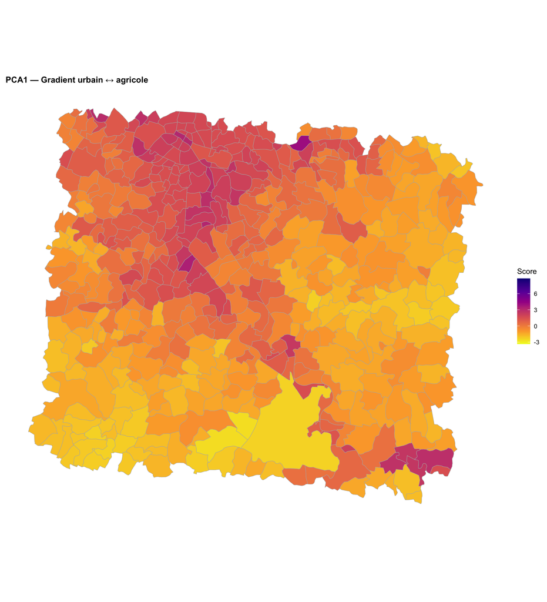

```r
# Ajout des scores PCA aux communes
communes_pca <- bind_cols(
  communes_clc,
  as.data.frame(pca_res$ind$coord[, 1:5]) %>%
    setNames(paste0("PCA", 1:5))
)

# Échelle commune pour comparaison
score_min <- min(communes_pca$PCA1, communes_pca$PCA2, communes_pca$PCA3,
                 communes_pca$PCA4, communes_pca$PCA5)
score_max <- max(communes_pca$PCA1, communes_pca$PCA2, communes_pca$PCA3,
                 communes_pca$PCA4, communes_pca$PCA5)

# Fonction pour créer une carte PCA
plot_pca_map <- function(data, var, title) {
  ggplot(data) +
    geom_sf(aes(fill = .data[[var]]), color = "grey70", size = 0.15) +
    scale_fill_viridis_c(
      option = "plasma",
      direction = -1,
      limits = c(score_min, score_max),
      name = "Score"
    ) +
    labs(title = title) +
    theme_minimal(base_size = 10) +
    theme(
      legend.position = "right",
      axis.text = element_blank(),
      axis.title = element_blank(),
      panel.grid = element_blank(),
      plot.title = element_text(face = "bold", size = 11)
    )
}

# Création des 5 cartes
p1 <- plot_pca_map(communes_pca, "PCA1", "PCA1 — Gradient urbain ↔ agricole")
p2 <- plot_pca_map(communes_pca, "PCA2", "PCA2 — Prairies / végétation naturelle")
p3 <- plot_pca_map(communes_pca, "PCA3", "PCA3 — Gradient forestier")
p4 <- plot_pca_map(communes_pca, "PCA4", "PCA4 — Transitions paysagères")
p5 <- plot_pca_map(communes_pca, "PCA5", "PCA5 — Zones humides / aquatiques")

# Affichage avec patchwork
p1
```

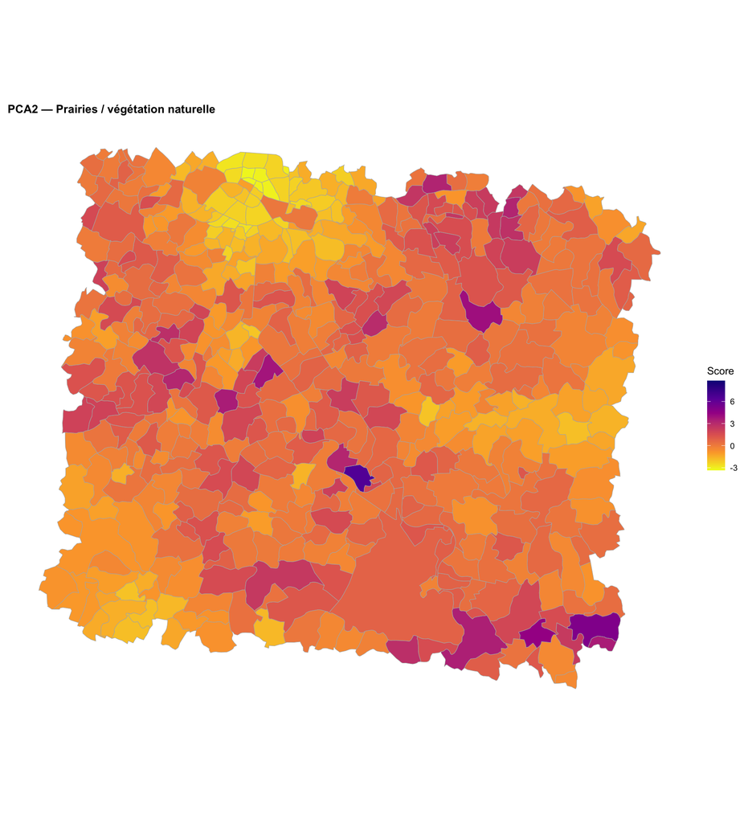

```r
p2
```

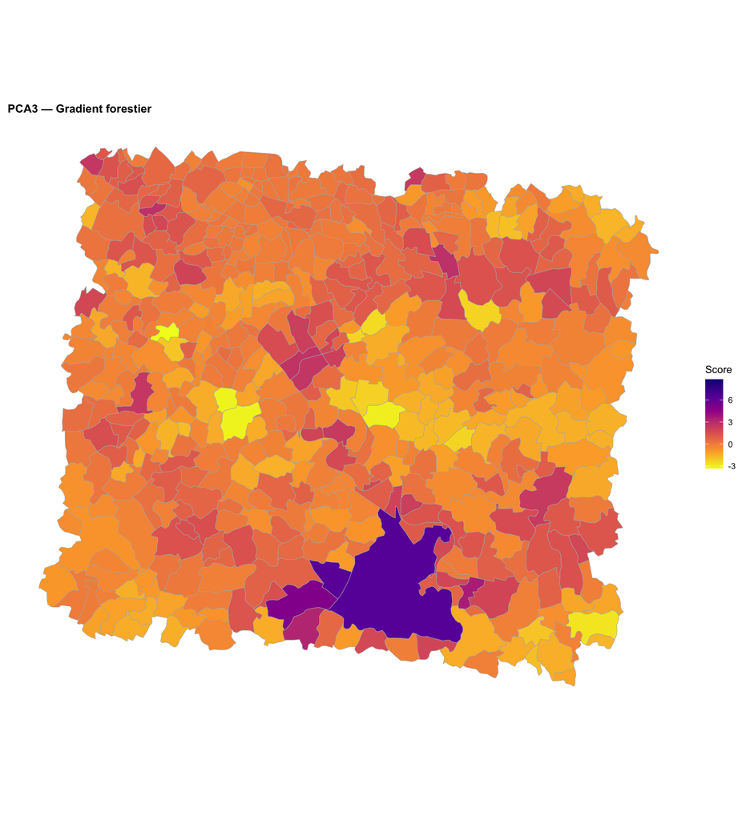

```r
p3
```

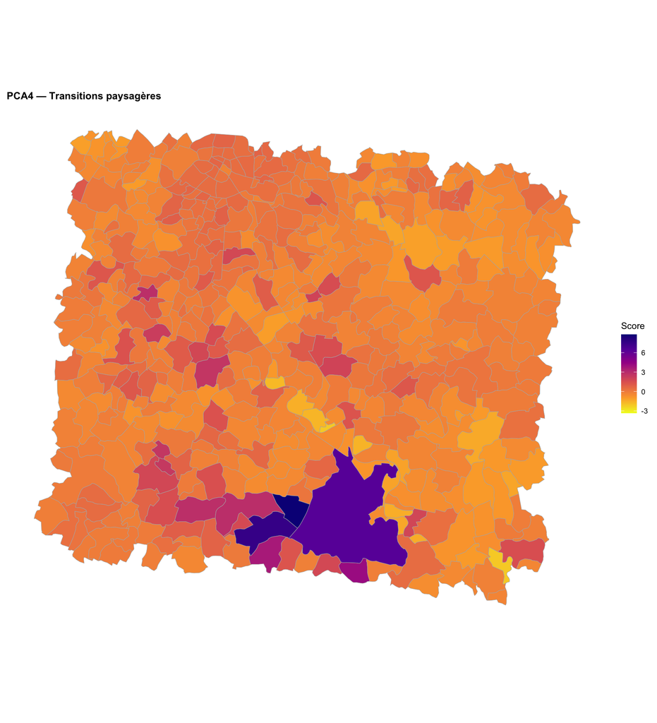

```r
p4
```

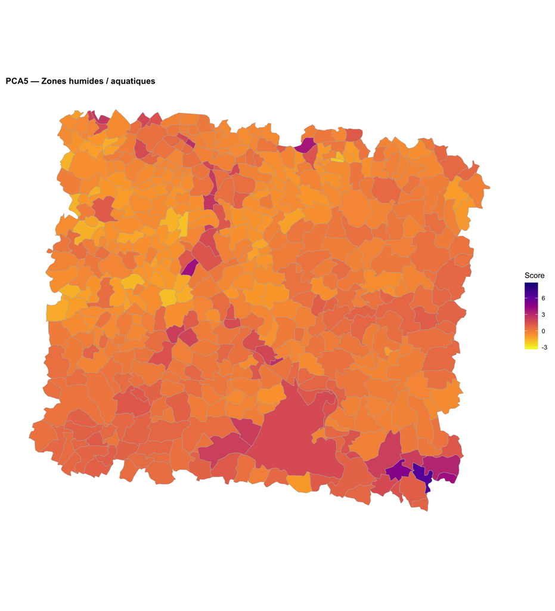

```r
p5
```

# 6 5. Classification K-means

La classification K-means permet de regrouper les communes en fonction de leur profil paysager, en utilisant les 5 premiers axes de l’ACP comme variables.

**Pourquoi utiliser les scores PCA ?**

L’utilisation des scores PCA plutôt que des classes originales réduit le bruit statistique et améliore la robustesse du clustering.

## 6.1 Détermination du nombre optimal de clusters

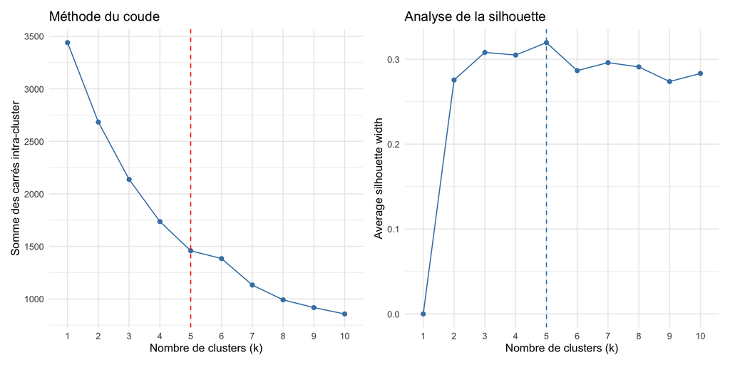

```r
# Extraction des coordonnées PCA
data_kmeans <- as.data.frame(pca_res$ind$coord[, 1:5])
colnames(data_kmeans) <- paste0("PCA", 1:5)

# Méthode du coude (elbow method)
p_elbow <- fviz_nbclust(data_kmeans, kmeans, method = "wss", k.max = 10) +
  geom_vline(xintercept = 5, linetype = 2, color = "red") +
  labs(
    title = "Méthode du coude",
    x = "Nombre de clusters (k)",
    y = "Somme des carrés intra-cluster"
  ) +
  theme_minimal()

# Méthode de la silhouette
p_silhouette <- fviz_nbclust(data_kmeans, kmeans, method = "silhouette", k.max = 10) +
  labs(
    title = "Analyse de la silhouette",
    x = "Nombre de clusters (k)"
  ) +
  theme_minimal()

# Affichage côte à côte
p_elbow | p_silhouette
```

## 6.2 Application du K-means

```r
# K-means avec k=5 (reproductibilité avec seed)
set.seed(1234)
k_opt <- 5
km_res <- kmeans(data_kmeans, centers = k_opt, nstart = 25)

# Ajout des clusters aux données
communes_km <- communes_pca
communes_km$cluster <- factor(km_res$cluster)

cat("🎯 Classification réalisée en", k_opt, "groupes\n")
```

```
🎯 Classification réalisée en 5 groupes
```

```r
cat("📊 Répartition des communes par cluster:\n")
```

```
📊 Répartition des communes par cluster:
```

```r
print(table(communes_km$cluster))
```

```
  1   2   3   4   5
 14 176 103 145  64
```

```r
cat("\n💯 Qualité du clustering (between_SS / total_SS):",
    round(km_res$betweenss / km_res$totss * 100, 2), "%\n")
```

```
💯 Qualité du clustering (between_SS / total_SS): 57.6 %
```

## 6.3 Caractérisation des clusters

Le tableau suivant montre le profil moyen de chaque cluster dans l’espace des composantes principales.

```r
# Moyennes des scores PCA par cluster
cluster_profiles <- aggregate(data_kmeans, by = list(Cluster = km_res$cluster), mean)

kable(
  cluster_profiles,
  digits = 2,
  caption = "Profil moyen des clusters dans l'espace des 5 PCA"
)
```

Profil moyen des clusters dans l’espace des 5 PCA

| Cluster | PCA1 | PCA2 | PCA3 | PCA4 | PCA5 |
| --- | --- | --- | --- | --- | --- |
| 1 | -1.56 | 0.82 | 2.56 | 3.34 | 1.00 |
| 2 | -0.13 | 0.55 | 0.81 | -0.52 | -0.30 |
| 3 | 1.76 | -1.53 | 0.05 | 0.22 | 0.01 |
| 4 | -1.44 | -0.53 | -0.75 | -0.08 | 0.28 |
| 5 | 1.14 | 1.98 | -1.17 | 0.54 | -0.02 |

```r
# Statistiques descriptives par cluster
cat("\n📊 Caractéristiques des clusters (classes CLC+ originales):\n\n")
```

```
📊 Caractéristiques des clusters (classes CLC+ originales):
```

```r
communes_km_summary <- communes_km %>%
  st_drop_geometry() %>%
  select(cluster, starts_with("class_")) %>%
  group_by(cluster) %>%
  summarise(across(starts_with("class_"), mean, .names = "{.col}"))

kable(communes_km_summary, digits = 1,
      caption = "Pourcentage moyen de chaque classe CLC+ par cluster")
```

Pourcentage moyen de chaque classe CLC+ par cluster

| cluster | class_1 | class_2 | class_3 | class_4 | class_5 | class_6 | class_7 | class_8 | class_9 | class_10 | class_11 |
| --- | --- | --- | --- | --- | --- | --- | --- | --- | --- | --- | --- |
| 1 | 5.5 | 16.5 | 40.1 | 0 | 0.2 | 8.8 | 27.9 | 0 | 0.5 | 0.5 | 0 |
| 2 | 19.1 | 1.0 | 45.5 | 0 | 0.2 | 14.3 | 18.4 | 0 | 0.3 | 1.2 | 0 |
| 3 | 75.8 | 0.1 | 13.1 | 0 | 0.1 | 7.6 | 0.8 | 0 | 0.3 | 2.2 | 0 |
| 4 | 6.2 | 0.7 | 18.6 | 0 | 0.1 | 10.1 | 63.7 | 0 | 0.2 | 0.3 | 0 |
| 5 | 31.1 | 0.5 | 23.0 | 0 | 0.4 | 20.1 | 20.6 | 0 | 1.3 | 2.9 | 0 |

**Typologie paysagère identifiée**

## 6.4 Carte des typologies paysagères

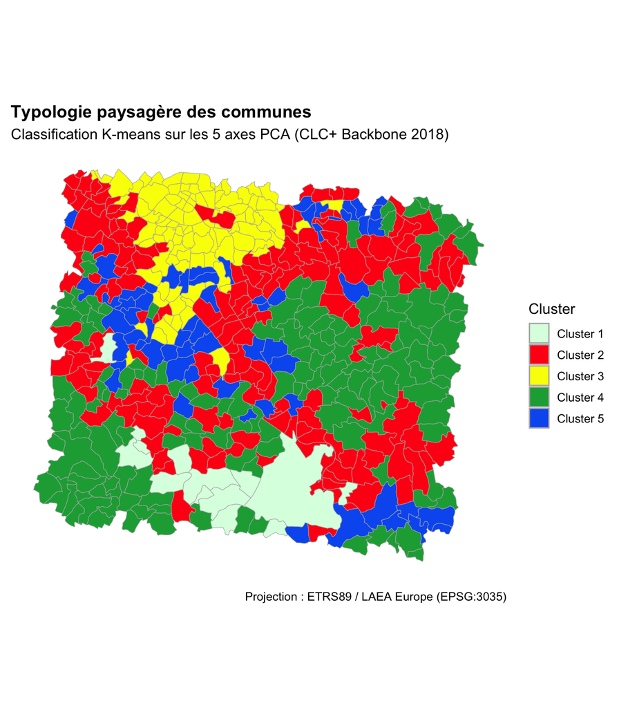

```r
ggplot(communes_km) +
  geom_sf(aes(fill = cluster), color = "grey70", size = 0.15) +
  scale_fill_manual(
    values = c("#dbffe2", "#FF0014", "#F9FF00", "#18a843", "#095FF1"),
    name = "Cluster",
    labels = paste("Cluster", 1:5)
  ) +
  labs(
    title = "Typologie paysagère des communes",
    subtitle = "Classification K-means sur les 5 axes PCA (CLC+ Backbone 2018)",
    caption = "Projection : ETRS89 / LAEA Europe (EPSG:3035)"
  ) +
  theme_minimal(base_size = 12) +
  theme(
    axis.text = element_blank(),
    axis.title = element_blank(),
    panel.grid = element_blank(),
    plot.title = element_text(face = "bold", size = 14),
    legend.position = "right"
  )
```

## 6.5 Visualisation dans l’espace PCA

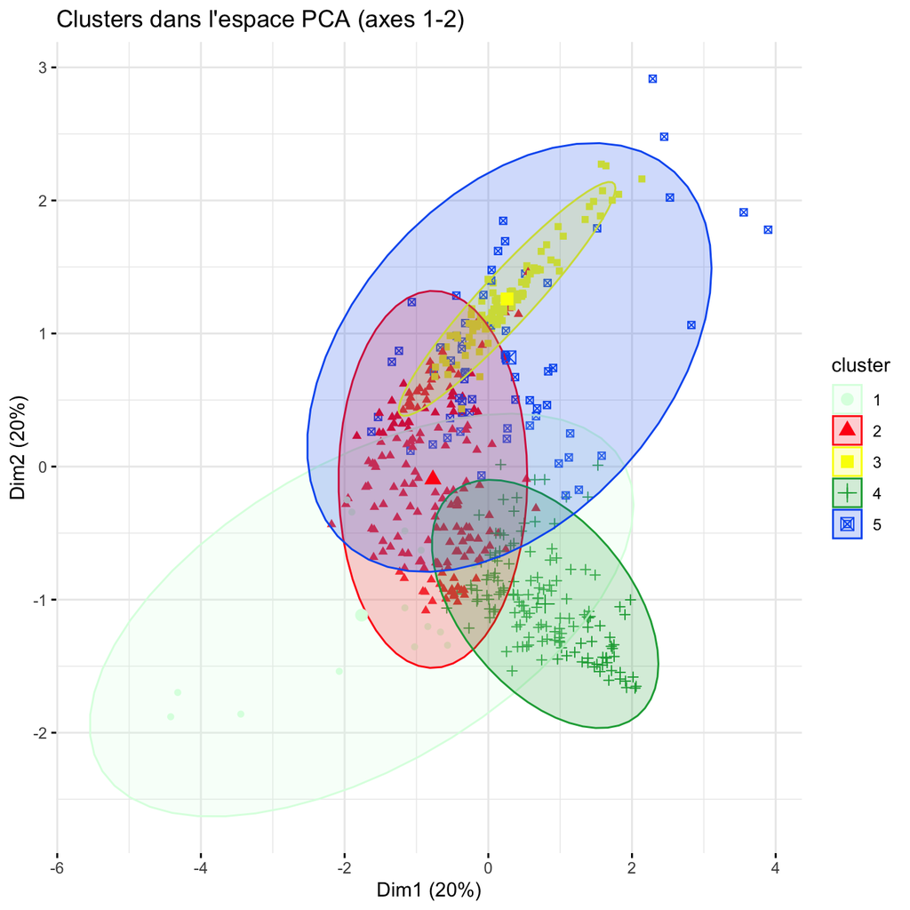

```r
fviz_cluster(
  km_res,
  data = data_kmeans,
  geom = "point",
  ellipse.type = "norm",
  palette = c("#dbffe2", "#FF0014", "#F9FF00", "#18a843", "#095FF1"),
  ggtheme = theme_minimal(),
  main = "Clusters dans l'espace PCA (axes 1-2)"
)
```

# 7 6. Synthèse et conclusion

## 7.1 Résultats principaux

Cette analyse a permis de :

1. **Extraire** les proportions de couverture du sol pour 11 classes CLC+ sur **502 communes** de la région parisienne
2. **Identifier** les principaux gradients paysagers via l’ACP :
   - 5 axes expliquant **85,7% de la variance totale**
   - Axe 1 : opposition urbain/agricole (24,2%)
   - Axe 2 : présence de prairies et végétation naturelle (23,0%)
3. **Classer** les communes en **5 typologies paysagères** distinctes avec une qualité de clustering de **57.6%**

## 7.2 Typologies paysagères identifiées

```r
# Résumé par cluster
summary_clusters <- communes_km %>%
  st_drop_geometry() %>%
  group_by(cluster) %>%
  summarise(
    N = n(),
    Urban = mean(class_1, na.rm = TRUE),
    Foret = mean(class_2 + class_3 + class_4, na.rm = TRUE),
    Agriculture = mean(class_7, na.rm = TRUE),
    Prairie = mean(class_6, na.rm = TRUE),
    .groups = "drop"
  )

kable(
  summary_clusters,
  digits = 1,
  col.names = c("Cluster", "N communes", "% Urbain", "% Forêt", "% Agriculture", "% Prairie"),
  caption = "Synthèse des typologies paysagères"
)
```

Synthèse des typologies paysagères

| Cluster | N communes | % Urbain | % Forêt | % Agriculture | % Prairie |
| --- | --- | --- | --- | --- | --- |
| 1 | 14 | 5.5 | 56.7 | 27.9 | 8.8 |
| 2 | 176 | 19.1 | 46.5 | 18.4 | 14.3 |
| 3 | 103 | 75.8 | 13.2 | 0.8 | 7.6 |
| 4 | 145 | 6.2 | 19.3 | 63.7 | 10.1 |
| 5 | 64 | 31.1 | 23.5 | 20.6 | 20.1 |

## 7.3 Applications et perspectives

### 7.3.1 Applications possibles

- **Aménagement du territoire** : identification de zones prioritaires pour la préservation d’espaces naturels
- **Études d’impact** : caractérisation du contexte paysager de projets d’infrastructure
- **Politiques environnementales** : ciblage d’actions selon les profils paysagers

### 7.3.2 Perspectives d’analyse

- **Analyse temporelle** : évolution des typologies avec plusieurs millésimes CLC+
- **Corrélations socio-économiques** : lien entre profils paysagers et indicateurs démographiques/économiques
- **Modélisation prédictive** : anticipation des changements de typologie
- **Analyse multi-échelle** : comparaison avec d’autres niveaux territoriaux (EPCI, départements)

# 8 Annexes

## 8.1 Données exportées

```r
# Export du fichier avec clusters
st_write(communes_km, "communes_typologie_paysagere.shp", delete_dsn = TRUE)

# Export des scores PCA en CSV
write.csv(
  communes_km %>% st_drop_geometry() %>%
    select(INSEE_COM, NOM_COM, cluster, starts_with("PCA"), starts_with("class_")),
  "communes_scores_pca_clusters.csv",
  row.names = FALSE
)
```

**À propos de ce document**